# CURSO DE ACTUALIZACION EN ESTADISTICA

#### Profesor: Dr. José Manuel MAGALLANES, Ph.D

## Sesión 9:

## **Medidas de Asociación Numérica-Numérica**

Traigamos los datos:

```r
# link a google:
lk="https://docs.google.com/spreadsheets/d/e/2PACX-1vRPPixYG_1dwhr8nQW-8VHq5Fel6s7ftYpiMYt_ZIcKdU3ZCa-x8D0Nkc9ojTVpmHkGkbclq5sHJLGK/pub?gid=0&single=true&output=csv"

# colectando datos
presupuesto=read.csv(lk,stringsAsFactors = F)
```

Veamos cómo se trajo la data:

```r
str(presupuesto)
```

```
## 'data.frame':    30 obs. of  12 variables:
##  $ sector        : chr  "01: PRESIDENCIA CONSEJO MINISTROS" "03: CULTURA" "04: PODER JUDICIAL" "05: AMBIENTAL" ...
##  $ sectorn       : chr  "PCM" "CUL" "PJ" "AMB" ...
##  $ pim2016G      : num  2.02e+09 5.43e+08 2.12e+09 6.49e+08 1.74e+09 ...
##  $ devengado2016G: num  1.70e+09 4.88e+08 2.09e+09 5.25e+08 1.49e+09 ...
##  $ girado2016G   : num  1.70e+09 4.87e+08 2.08e+09 5.24e+08 1.49e+09 ...
##  $ pim2016I      : num  1.13e+09 2.28e+08 2.46e+08 3.70e+08 8.57e+08 ...
##  $ Recaudado2016 : num  1.39e+09 2.70e+08 2.48e+08 3.96e+08 9.77e+08 ...
##  $ pim2018G      : num  7.24e+09 6.19e+08 2.49e+09 6.82e+08 2.17e+09 ...
##  $ devengado2018G: num  5.30e+09 5.84e+08 2.38e+09 6.24e+08 1.73e+09 ...
##  $ girado2018G   : num  5.30e+09 5.83e+08 2.38e+09 6.24e+08 1.73e+09 ...
##  $ pim2018I      : num  3.13e+09 2.56e+08 2.94e+08 3.48e+08 9.17e+08 ...
##  $ Recaudado2018 : num  2.70e+09 4.07e+08 3.20e+08 4.29e+08 8.76e+08 ...
```

Calculemos la razon girado-recaudado para cada año:

```r
# para 2016
presupuesto$girareca2016=presupuesto$girado2016G/presupuesto$Recaudado2016

# para 2018
presupuesto$girareca2018=presupuesto$girado2018G/presupuesto$Recaudado2018
```

Sabiendo lo anterior, nuestra curiosidad aumenta en saber si las tasa obtenidas tienen correlación.

### Correlación

Exploremos el coeficiente de correlación:

```r
cor.test(~girareca2016 + girareca2018, data = presupuesto)
```

```
##
##  Pearson's product-moment correlation
##
## data:  girareca2016 and girareca2018
## t = 5.9303, df = 28, p-value = 2.208e-06
## alternative hypothesis: true correlation is not equal to 0
## 95 percent confidence interval:
##  0.5277477 0.8720102
## sample estimates:
##       cor
## 0.7461504
```

Esto sugiere que ambas variables se correlacionan positivamente. La intensidad de la correlación es alta. Eso lo vemos aquí:

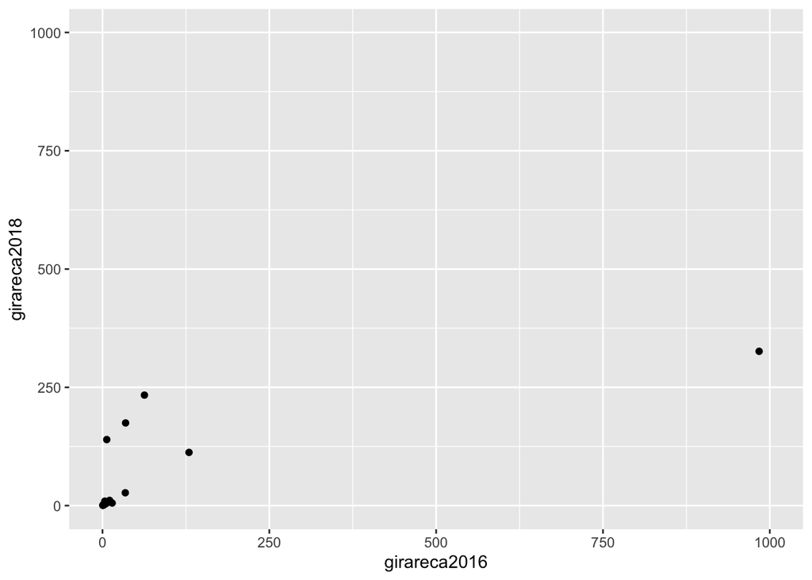

```r
library(ggplot2)
base = ggplot(presupuesto, aes(girareca2016, girareca2018, label = sectorn))
scatterplot1 = base + geom_point()  +
              xlim(0,1000) + ylim(0,1000)
scatterplot1
```

La correlación es alta, pero parece que el atípico ha influido en ello. Graficaré aquí la diagonal.

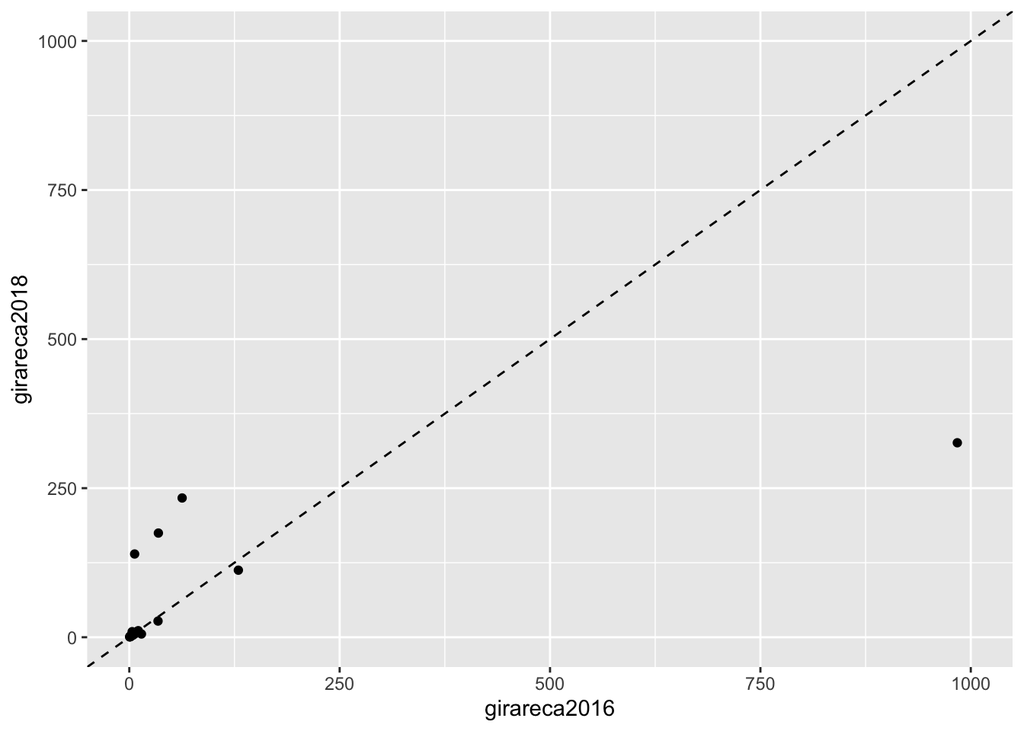

```r
scatterplot2 = scatterplot1 + geom_abline(linetype = "dashed")
scatterplot2
```

Veamos cada sector:

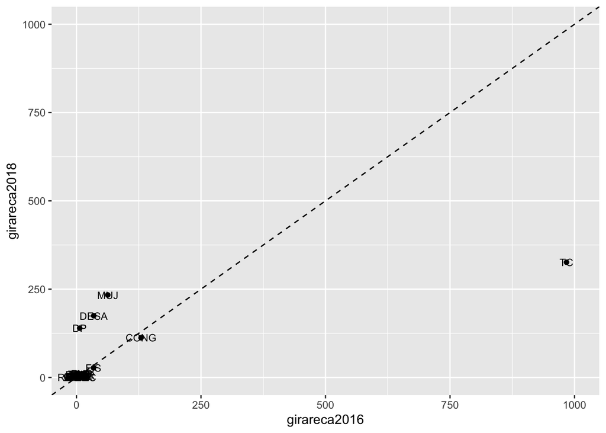

```r
scatterplot2 + geom_text(size = 3)
```

Mejoremos las etiquetas:

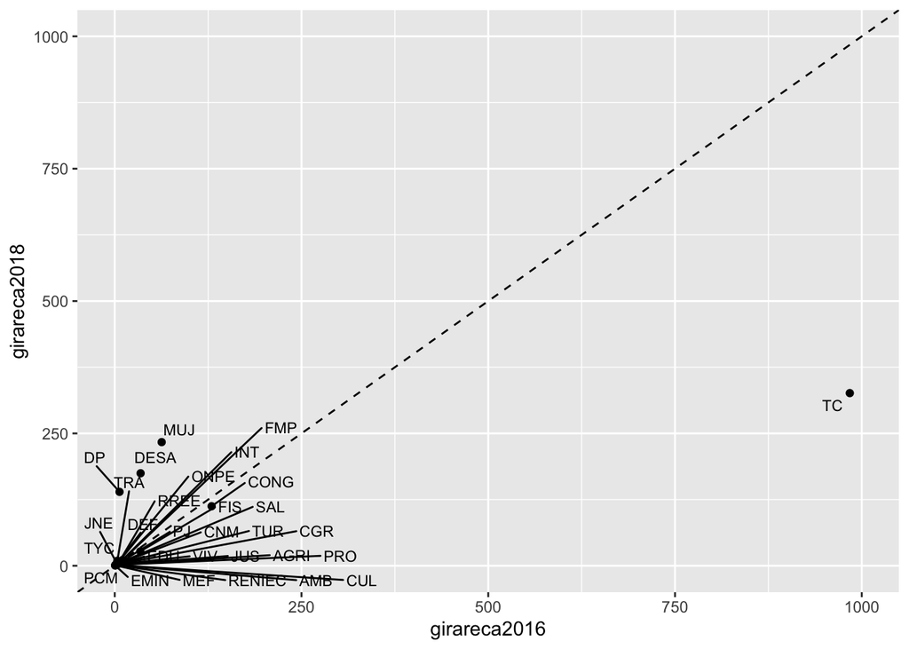

```r
library(ggrepel)

scatterplot2 +geom_text_repel(size=3)
```

Recalculemos sin el TC:

```r
# eliminando fila:
presupuestoNOtc=presupuesto[presupuesto$sectorn!='TC',]

# recalculando Pearson:
cor.test(~girareca2016 + girareca2018, data = presupuestoNOtc)
```

```
##
##  Pearson's product-moment correlation
##
## data:  girareca2016 and girareca2018
## t = 4.3661, df = 27, p-value = 0.000167
## alternative hypothesis: true correlation is not equal to 0
## 95 percent confidence interval:
##  0.3622035 0.8171506
## sample estimates:
##     cor
## 0.64331
```

La correlación baja, pero sigue siendo considerable:

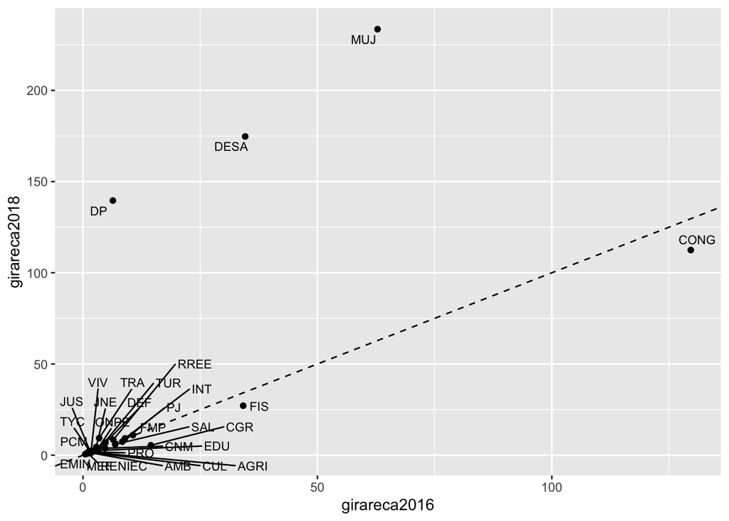

```r
baseN = ggplot(presupuestoNOtc, aes(girareca2016, girareca2018, label = sectorn))
scatterplotN1 = baseN + geom_point() + geom_abline(linetype = "dashed")
scatterplotN1 +geom_text_repel(size=3)
```

Hagamos zoom:

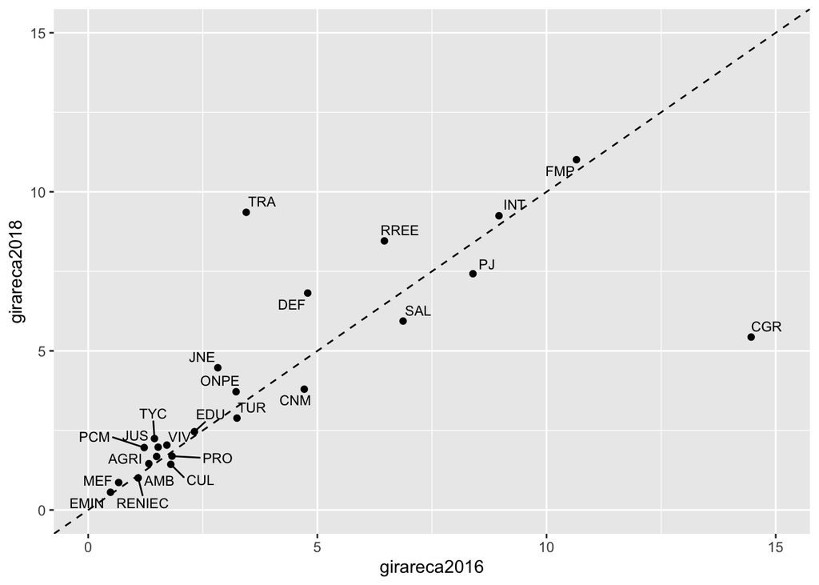

```r
baseN = ggplot(presupuestoNOtc, aes(girareca2016, girareca2018, label = sectorn))
scatterplotN1 = baseN + geom_point()  +
              xlim(0,15) + ylim(0,15) + geom_abline(linetype = "dashed")
scatterplotN1 +geom_text_repel(size=3)
```

Este conjunto de sectores tiene un comportamiento tal que eleva para toda la data la correlación.

### Regresión

La regresión es un salto interesante a partir de la correlación, pues esta vez sí podemos saber el efecto de una variable, habiendo ‘contenido’ o ‘controlado’ el efecto de las demás presentes en el modelo. Planteamos aqui que el monto recaudado a nivel de gobierno central está influenciado por como se manejo los gastos e ingresos en el 2016:

```r
regre=lm(Recaudado2018~pim2016G + devengado2016G + girado2016G + pim2016I + Recaudado2016,
         data = presupuesto)
summary(regre)
```

```
##
## Call:
## lm(formula = Recaudado2018 ~ pim2016G + devengado2016G + girado2016G +
##     pim2016I + Recaudado2016, data = presupuesto)
##
## Residuals:
##        Min         1Q     Median         3Q        Max
## -579182093 -205974120 -152034926  -50752580 1378684346
##
## Coefficients:
##                  Estimate Std. Error t value Pr(>|t|)
## (Intercept)     2.055e+08  1.088e+08   1.888  0.07117 .
## pim2016G       -6.184e-02  4.196e-01  -0.147  0.88406
## devengado2016G  9.870e+00  9.606e+00   1.028  0.31443
## girado2016G    -9.828e+00  9.642e+00  -1.019  0.31823
## pim2016I       -1.679e-01  4.368e-01  -0.384  0.70409
## Recaudado2016   9.333e-01  2.614e-01   3.571  0.00155 **
## ---
## Signif. codes:  0 '***' 0.001 '**' 0.01 '*' 0.05 '.' 0.1 ' ' 1
##
## Residual standard error: 471500000 on 24 degrees of freedom
## Multiple R-squared:  0.9915, Adjusted R-squared:  0.9898
## F-statistic: 562.6 on 5 and 24 DF,  p-value: < 2.2e-16
```

```r
regre2=lm(Recaudado2018~pim2016G + devengado2016G + girado2016G + pim2016I + Recaudado2016,
         data = presupuestoNOtc)
summary(regre2)
```

```
##
## Call:
## lm(formula = Recaudado2018 ~ pim2016G + devengado2016G + girado2016G +
##     pim2016I + Recaudado2016, data = presupuestoNOtc)
##
## Residuals:
##        Min         1Q     Median         3Q        Max
## -577276093 -217666427 -159198281  -59910571 1372034227
##
## Coefficients:
##                  Estimate Std. Error t value Pr(>|t|)
## (Intercept)     2.169e+08  1.137e+08   1.907  0.06909 .
## pim2016G       -6.631e-02  4.270e-01  -0.155  0.87795
## devengado2016G  9.682e+00  9.781e+00   0.990  0.33253
## girado2016G    -9.636e+00  9.818e+00  -0.981  0.33656
## pim2016I       -1.737e-01  4.445e-01  -0.391  0.69951
## Recaudado2016   9.375e-01  2.661e-01   3.523  0.00182 **
## ---
## Signif. codes:  0 '***' 0.001 '**' 0.01 '*' 0.05 '.' 0.1 ' ' 1
##
## Residual standard error: 479700000 on 23 degrees of freedom
## Multiple R-squared:  0.9916, Adjusted R-squared:  0.9897
## F-statistic: 541.2 on 5 and 23 DF,  p-value: < 2.2e-16
```

Vemos que a nivel de regresión no ha tenido mayor efecto el atípico encontrado. ____

[Volver al programa del curso](https://coursesandtutorials.github.io/Estadistica/)